# Higher Prelim Topic Revision - Web Version

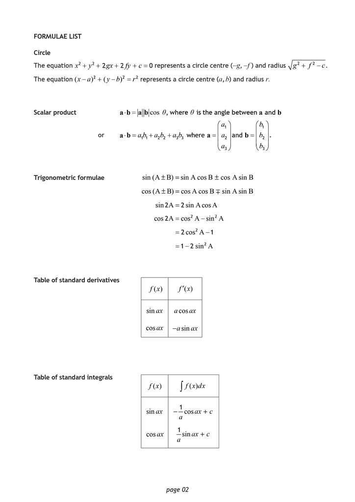

## 13 The Circle

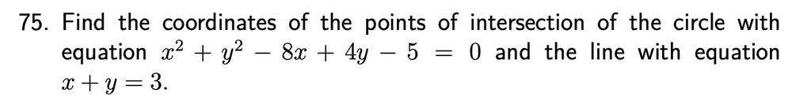

Points of intersection can be found by solving simultaneous equations. For a line intersecting a circle, first get the line's equation in a suitable form then solve through *substitution*.

$(1,2)$ and $(8,-5)$

*For more practice, try:* [1, 3 and 5 from these past exam questions.](https://www.dynamicmaths.co.uk/QuestionBank/get_questions_handler.php?levelQ=6&otherlevellist=empty&how=A&topics%5B%5D=213&orderR=dateA&calc=CN&noQ=500&minmarks=0&maxmarks=999&NR=RO&interleaved=NA&MC=MCA)

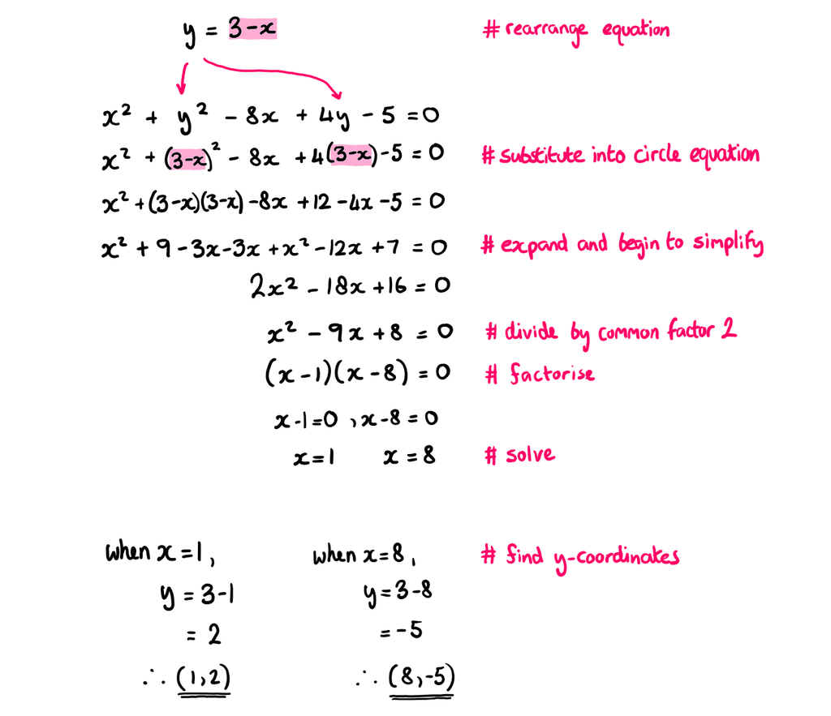

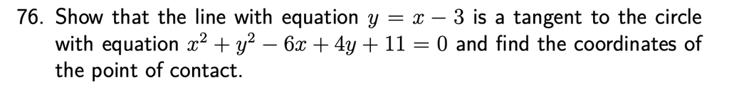

Finding points of contact for a line tangent to a circle, or showing that a line is a tangent to a circle, can be approached just as a special case of finding *points of intersection*. Follow the approach of the previous question, and look at how the resulting quadratic factorises to *show tangency*.

$(2,-1)$ and *repeated factors therefore the line is a tangent to the circle*.

*For more practice, try:* [2, 4 and 6 from these past exam questions.](https://www.dynamicmaths.co.uk/QuestionBank/get_questions_handler.php?levelQ=6&otherlevellist=empty&how=A&topics%5B%5D=213&orderR=dateA&calc=CN&noQ=500&minmarks=0&maxmarks=999&NR=RO&interleaved=NA&MC=MCA)

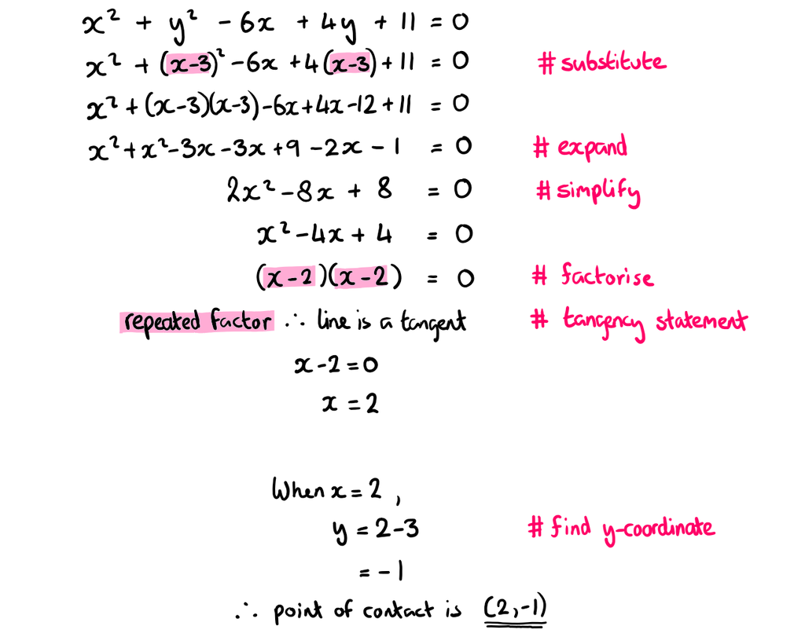

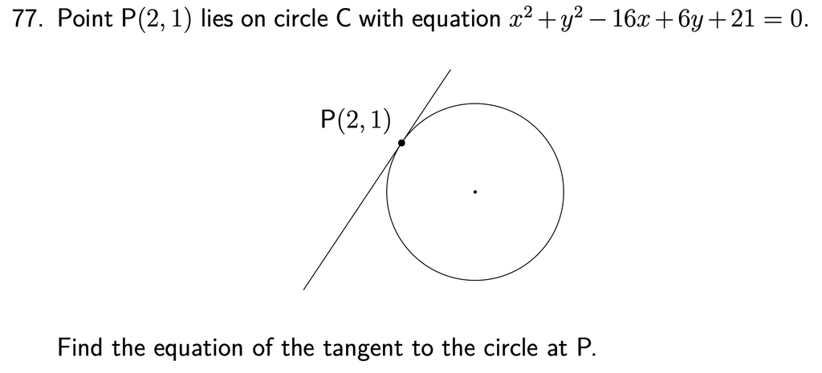

Unlike finding a tangent to other curves earlier in the course, finding the gradient of a tangent to a circle will *not involve differentiation*. Instead, start by finding the gradient of the **radius** which meets the tangent at the point of contact, and consider its gradient might lead to the gradient of the *tangent*.

$y=\frac{3}{2}x-2$ or $2y=3x-4$

*For more practice, try:* [these past exam questions.](https://www.dynamicmaths.co.uk/QuestionBank/get_questions_handler.php?levelQ=6&otherlevellist=empty&how=A&topics%5B%5D=212&orderR=dateA&calc=CN&noQ=500&minmarks=0&maxmarks=999&NR=RO&interleaved=NA&MC=MCA)

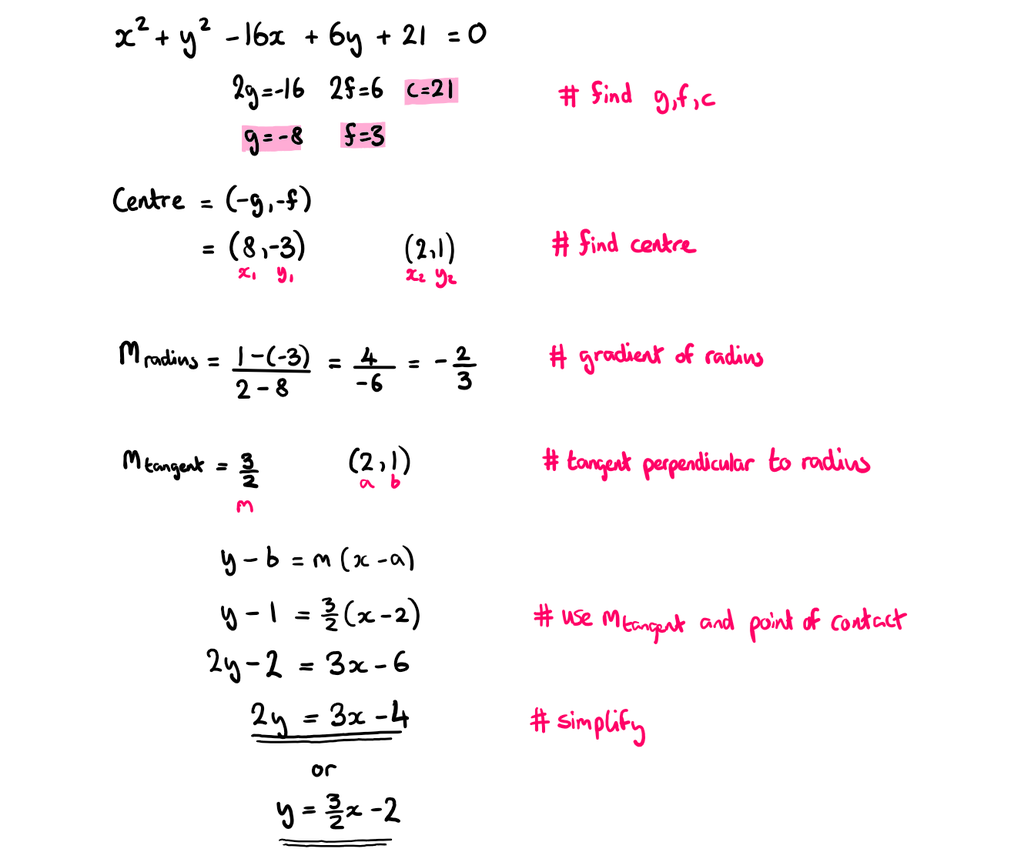

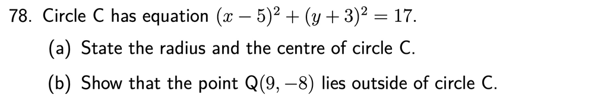

For (a) remember that the formula sheet states the connection between the equation of a circle and its radius and centre.

For (b) it would help to know *the* **distance** *the point is from the centre of the circle*.

1. Centre $(5,-3)$ and radius $\sqrt{17}$.
2. $\sqrt{41}>\sqrt{17}$ so the point lies outside the circle (or other valid approach).

*For more practice, try:* [Zeta Higher Tetbook](https://ebooks.zetapress.co.uk/yyrtww/books) Page 50, Exercise 3.4, Q1 parts (a), (b) and (c)

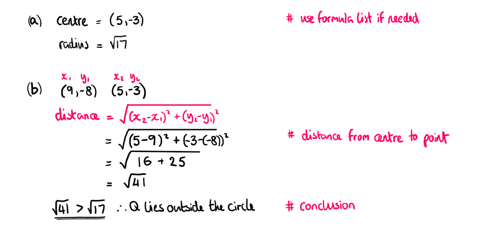

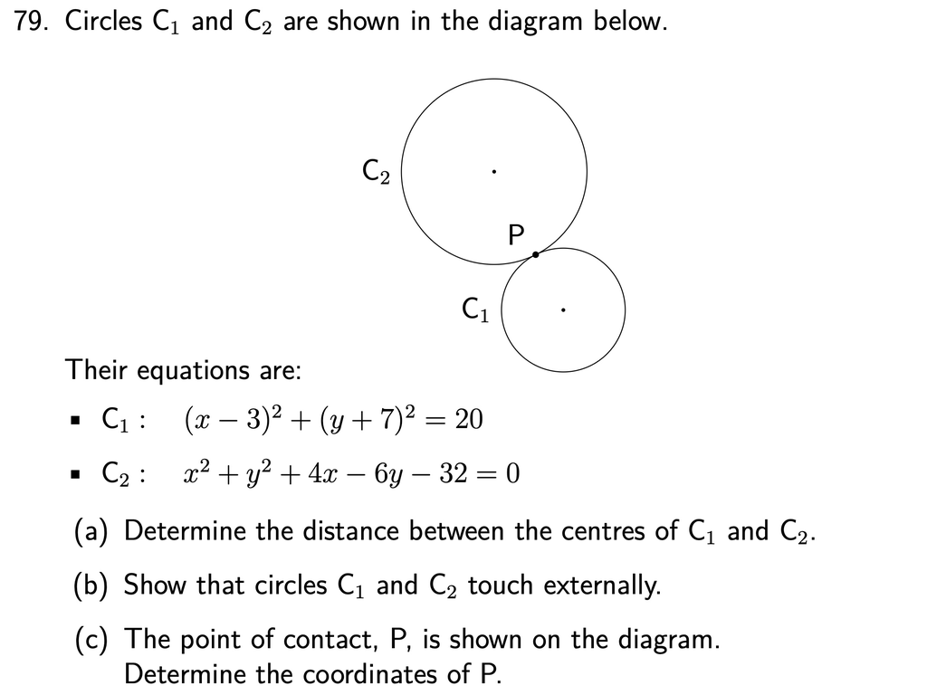

Using the *distance formula* to find the answer to part (a) will be needed for part (b). Consider the radii of each circle. What is their *sum*?

For part (c), the radii of the circle have already been found. The ratio of the radii is the *ratio in which the point P divides the line between the centres*. This skill was previously introduced in the *Vectors* topic.

1. $\sqrt{125}$ or $5\sqrt{5}$
2. $3\sqrt{5}+2\sqrt{5}=5\sqrt{5}$ and conclusion, or other valid approach.
3. $(1,-3)$

*For more practice, try:* [Zeta Higher Tetbook](https://ebooks.zetapress.co.uk/yyrtww/books), Page 60, Exercise 3.9b, Q1(a).

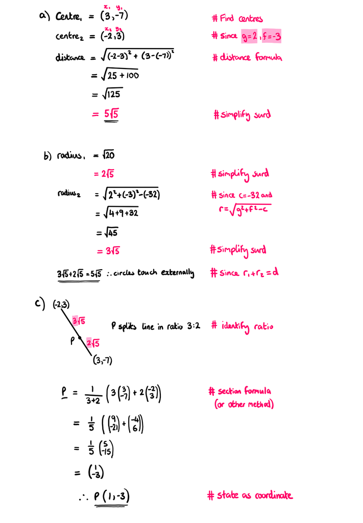

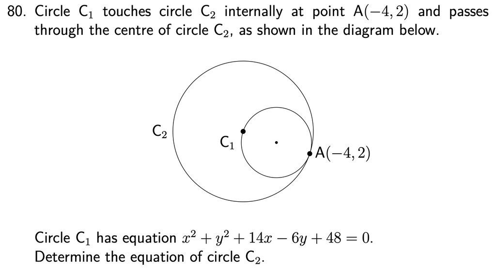

For any problem-solving circle question, if an equation of a circle is given then a good starting point is to find its centre and radius.

To find the equation of a circle, both its *centre* and *radius* is needed. How do the sizes of the two circles compare?

$(x+10)^2+(y-4)^2=40$

*For more practice, try:* [1, 2, 6 and 8 from these past exam questions.](https://www.dynamicmaths.co.uk/QuestionBank/get_questions_handler.php?levelQ=6&otherlevellist=empty&how=A&topics%5B%5D=214&orderR=dateA&calc=CN&noQ=500&minmarks=0&maxmarks=999&NR=RN&interleaved=NA&MC=MCA)

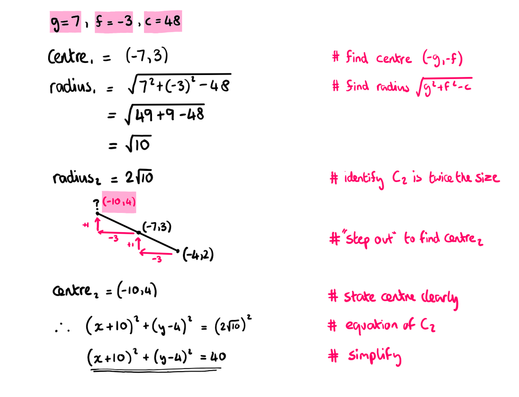

## 14 Wave Function

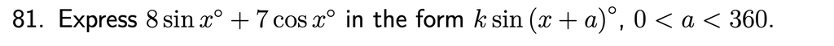

Start by *expanding* $k\sin{(x+a)^{\circ}}$, using the formula sheet to help, and hence find the values of $k\sin{a}^{\circ}$ and $k\cos{a^{\circ}}$.

How can $k$ and $a$ be then found?

$\sqrt{113}\sin{(x+41.2)^{\circ}}$

*For more practice, try:* [11, 25, and 29 from these past exam questions.](https://www.dynamicmaths.co.uk/QuestionBank/get_questions_handler.php?levelQ=6&otherlevellist=3&how=A&topics%5B%5D=237&orderR=dateA&calc=CN&noQ=500&minmarks=0&maxmarks=999&NR=RN&interleaved=NA&MC=MCA)

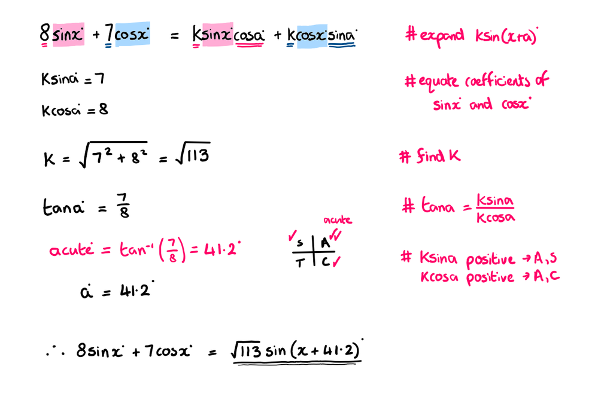

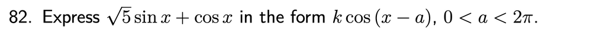

Take care with *negatives* when finding $k\sin{a}$ and $k\cos{a}$.

What does $0<a<2\pi$ tell you about the final answer?

$\sqrt{6}\cos{(x-1.15)}$

*For more practice, try:* [14, 18a, and 19a from these past exam questions.](https://www.dynamicmaths.co.uk/QuestionBank/get_questions_handler.php?levelQ=6&otherlevellist=3&how=A&topics%5B%5D=237&orderR=dateA&calc=CN&noQ=500&minmarks=0&maxmarks=999&NR=RN&interleaved=NA&MC=MCA)

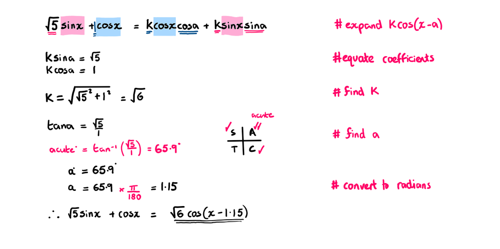

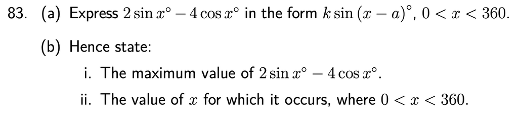

Take care with part (a), as mistakes here can make part (b) more difficult.

For part (b), use your answer for part (a). What is the maximum value on the graph of $y=\sin{x}^{\circ}$, and for what value of $x$ does it occur? If you can work out the answer to that, think about how the graph of $y=k\sin{(x-a)^{\circ}}$ has been *transformed*.

1. $2\sqrt{5}\sin{(x-63.4)^{\circ}}$
2. Max value of $2\sqrt{5}$ occurs when $x=153.4$

*For more practice, try:* [3, 5 and 8 from these past exam questions.](https://www.dynamicmaths.co.uk/QuestionBank/get_questions_handler.php?levelQ=6&otherlevellist=3&how=A&topics%5B%5D=237&orderR=dateA&calc=CN&noQ=500&minmarks=0&maxmarks=999&NR=RN&interleaved=NA&MC=MCA)

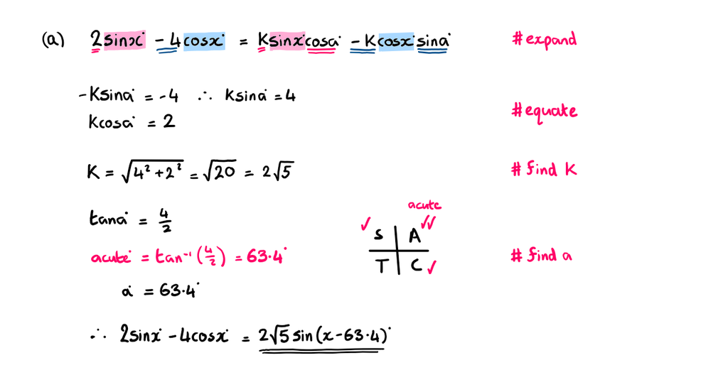

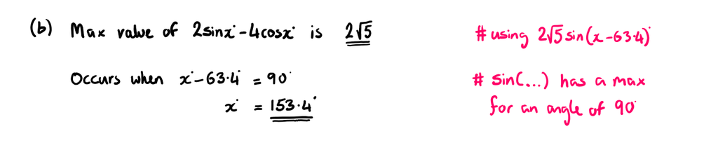

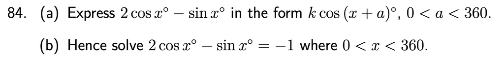

Once part (a) has been carefully completed, the answer should be used to solve the equation in part (b).

1. $\sqrt{5}\cos{(x+26.6)^{\circ}}$
2. $x=90,216.8$

*For more practice, try:* [1, 4, and 6 from these past exam questions.](https://www.dynamicmaths.co.uk/QuestionBank/get_questions_handler.php?levelQ=6&otherlevellist=3&how=A&topics%5B%5D=237&orderR=dateA&calc=CN&noQ=500&minmarks=0&maxmarks=999&NR=RN&interleaved=NA&MC=MCA)

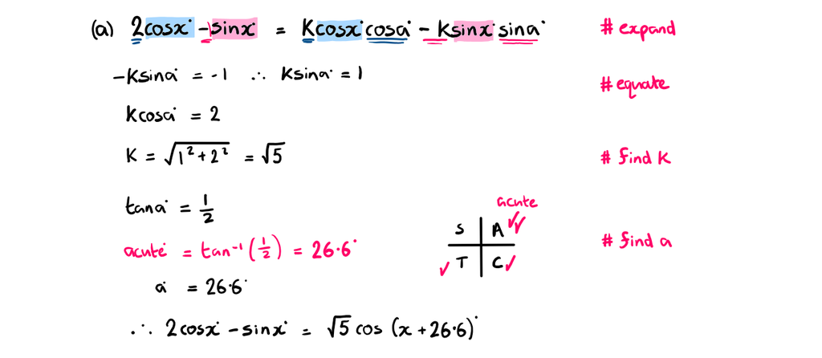

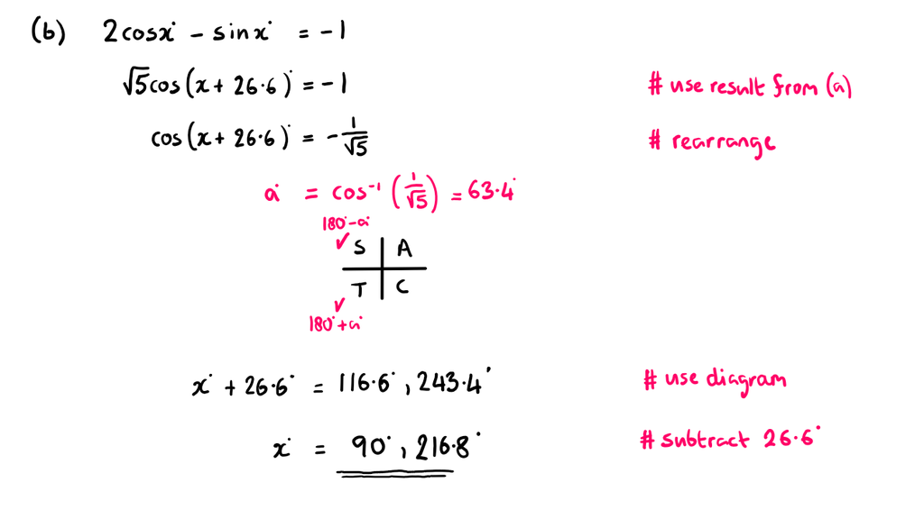

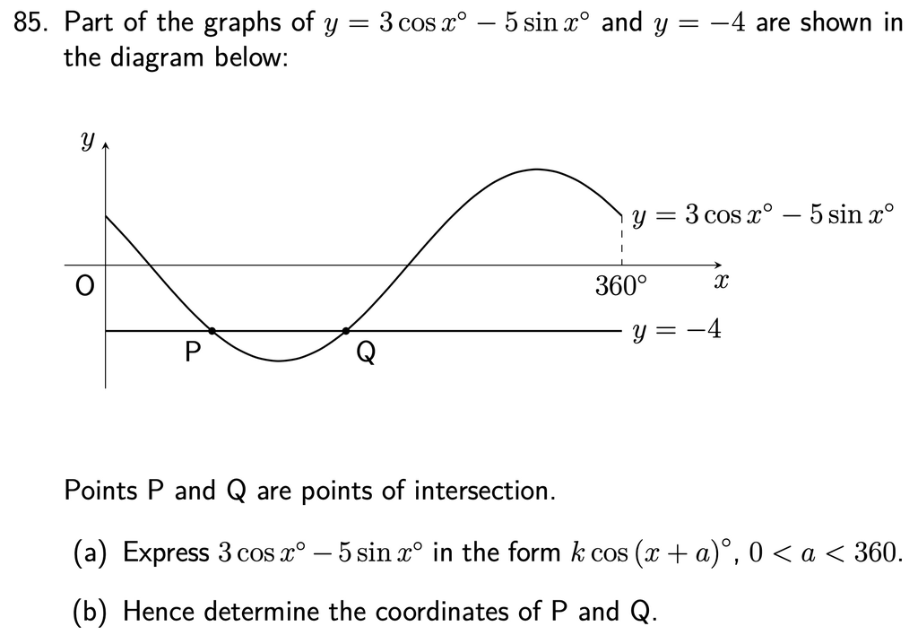

Finding *points of intersection* P and Q requires solving *simulaneous equations*. Note that here, both equations are written in the form $y=\dots$

Remember to state your answers as *full coordinates*, labelled P and Q.

*For more practice, try:* [7 from these past exam questions.](https://www.dynamicmaths.co.uk/QuestionBank/get_questions_handler.php?levelQ=6&otherlevellist=3&how=A&topics%5B%5D=237&orderR=dateA&calc=CN&noQ=500&minmarks=0&maxmarks=999&NR=RN&interleaved=NA&MC=MCA)

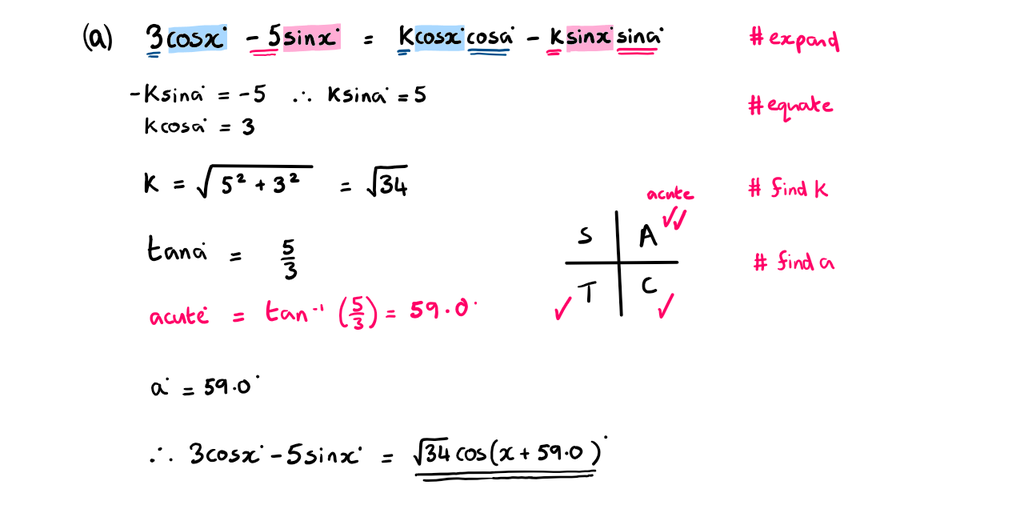

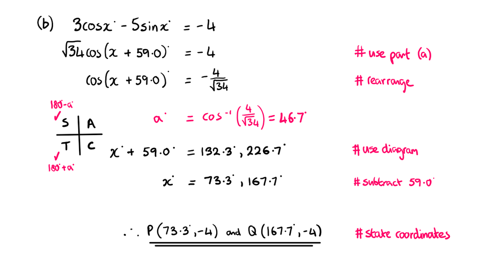